# Data Visualization with `ggplot2`

### Appearance

`ggplot2` package provides several functions that improves the appearance of the plot, and thus we have a visual that has the ideal graph properties.

The appearance of ggplot objects can be improved using themes in ggplot2 package and other theme packages such as `ggtheme` and `bbplot`.

We will consider two scenarios. In the first one, our purpose is just to illustrate the frequency of each diamond cut type. On the other hand, we will emphasize the number of very good cut diamonds in the second one. **Scenario 1**

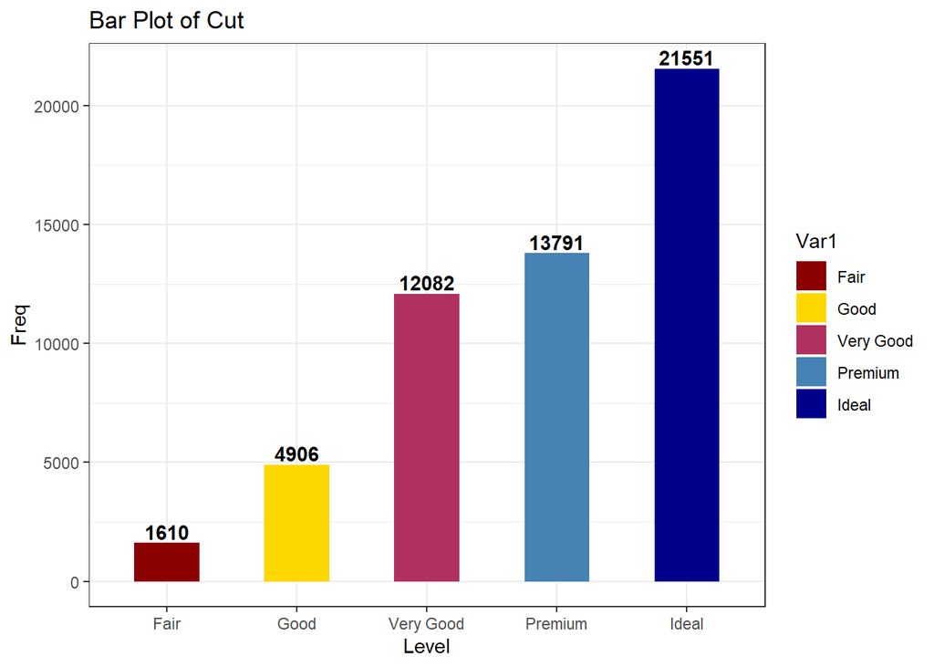

```r
ggplot(df,aes(x=Var1,y=Freq,fill=Var1))+geom_bar(stat="identity",width=0.5)+
  labs(title="Bar Plot of Cut",y="Freq",x="Level")+scale_fill_manual(values=c("darkred","gold1","maroon","steelblue","darkblue"))+geom_text(aes(label=Freq),vjust=-0.25,fontface="bold")+theme_bw()
```

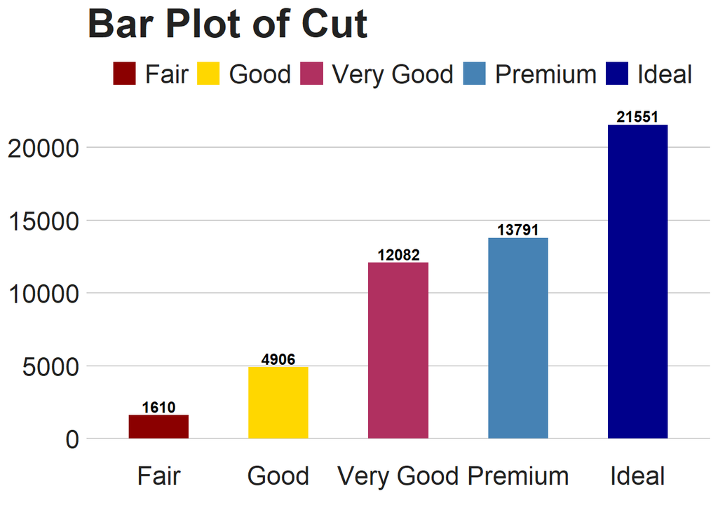

```r
library(bbplot)
ggplot(df,aes(x=Var1,y=Freq,fill=Var1))+geom_bar(stat="identity",width=0.5)+
  labs(title="Bar Plot of Cut",y="Freq",x="Level")+scale_fill_manual(values=c("darkred","gold1","maroon","steelblue","darkblue"))+geom_text(aes(label=Freq),vjust=-0.25,fontface="bold")+bbc_style()
```

You can also use `theme()` function for customization.

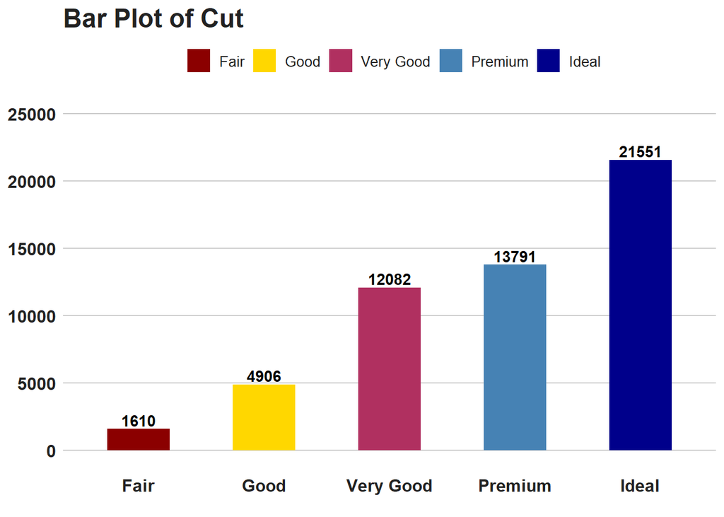

```r
library(bbplot)
ggplot(df,aes(x=Var1,y=Freq,fill=Var1))+geom_bar(stat="identity",width=0.5)+ylim(0,25000)+
  labs(title="Bar Plot of Cut",y="Freq",x="Level")+scale_fill_manual(values=c("darkred","gold1","maroon","steelblue","darkblue"))+geom_text(aes(label=Freq),vjust=-0.25,fontface="bold")+bbc_style()+
  theme(plot.title = element_text(size=18),axis.text = element_text(size=12,face="bold"),legend.text = element_text(size=10))
```

In an ideal bar plot, the bar starts with the highest one.

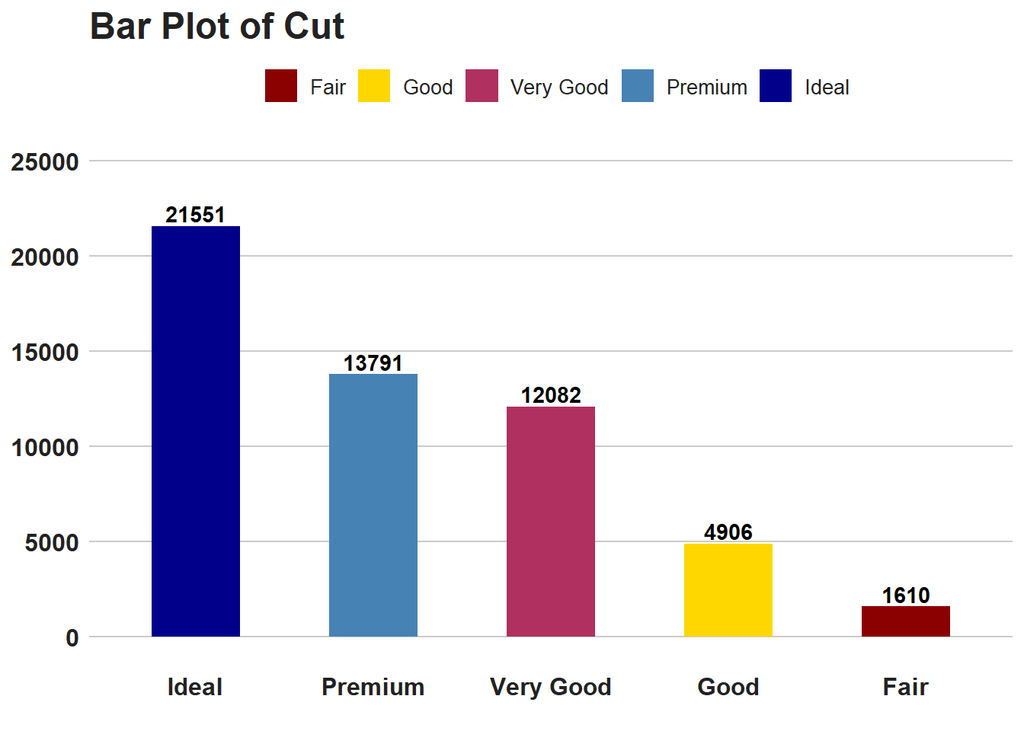

```r
library(bbplot)
ggplot(df,aes(x=reorder(Var1,-Freq),y=Freq,fill=Var1))+geom_bar(stat="identity",width=0.5)+ylim(0,25000)+
  labs(title="Bar Plot of Cut",y="Freq",x="Level")+scale_fill_manual(values=c("darkred","gold1","maroon","steelblue","darkblue"))+geom_text(aes(label=Freq),vjust=-0.25,fontface="bold")+bbc_style()+
  theme(plot.title = element_text(size=18),axis.text = element_text(size=12,face="bold"),legend.text = element_text(size=10))
```

When you use labels on the top of the bar, you do not need to use y axis.

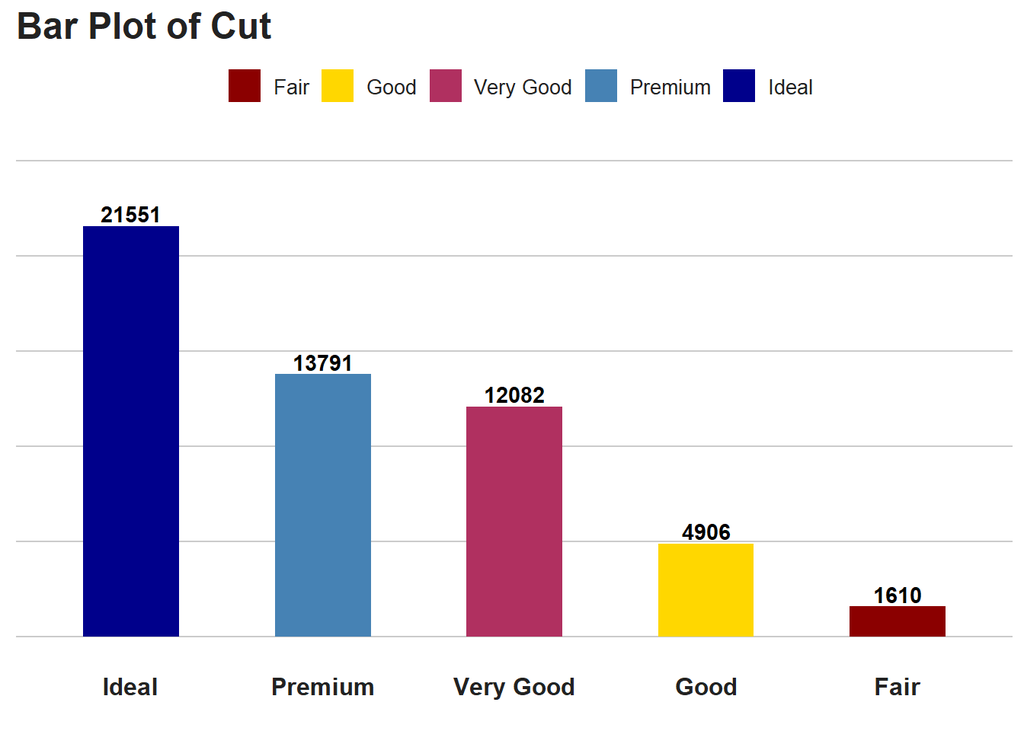

```r
library(bbplot)
ggplot(df,aes(x=reorder(Var1,-Freq),y=Freq,fill=Var1))+geom_bar(stat="identity",width=0.5)+ylim(0,25000)+
  labs(title="Bar Plot of Cut",y="Freq",x="Level")+scale_fill_manual(values=c("darkred","gold1","maroon","steelblue","darkblue"))+geom_text(aes(label=Freq),vjust=-0.25,fontface="bold")+bbc_style()+
  theme(plot.title = element_text(size=18),axis.text = element_text(size=12,face="bold"),legend.text = element_text(size=10),axis.text.y = element_blank())
```

Then, put the legend on the top left of the plot.

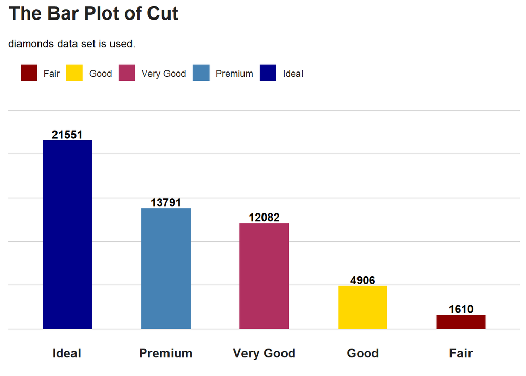

```r
library(bbplot)
ggplot(df,aes(x=reorder(Var1,-Freq),y=Freq,fill=Var1))+geom_bar(stat="identity",width=0.5)+ylim(0,25000)+
  labs(title="The Bar Plot of Cut",y="Freq",x="Level",subtitle ="diamonds data set is used.")+scale_fill_manual(values=c("darkred","gold1","maroon","steelblue","darkblue"))+geom_text(aes(label=Freq),vjust=-0.25,fontface="bold")+bbc_style()+
  theme(plot.title = element_text(size=18),plot.subtitle = element_text(size=10),axis.text = element_text(size=12,face="bold"),legend.text = element_text(size=9),axis.text.y = element_blank(),legend.position='top',
        legend.justification='left',
        legend.direction='horizontal')
```

If our purpose is to emphasize the very good diamond cuts, we will use Gestalt Principle.

[figure not shown]

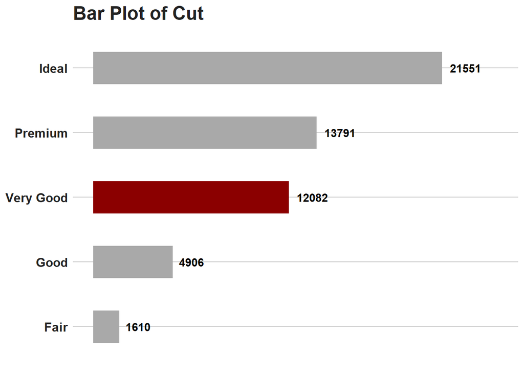

```r
library(bbplot)
ggplot(df,aes(x=Var1,y=Freq,fill=Var1))+geom_bar(stat="identity",width=0.5)+ylim(0,25000)+
  labs(title="Bar Plot of Cut",y="Freq",x="Level")+scale_fill_manual(values=c("darkgrey","darkgrey","darkred","darkgrey","darkgrey"))+geom_text(aes(label=Freq),hjust=-0.25,fontface="bold")+bbc_style()+coord_flip()+
  theme(plot.title = element_text(size=18),axis.text = element_text(size=12,face="bold"),legend.text = element_text(size=10),axis.text.x = element_blank(),legend.position='none')
```

You can see more details from [my lecture note for data visualization.](https://metustat112.github.io/Recitation%205/Stat-112-Recitation-5.html)

## Drawing a Map in R

**Mapping with Leaflet**

Leaflet is one of the most popular open-source JavaScript libraries for interactive maps. It provides features like Interactive panning/zooming, Map tiles, Markers, Polygons, Lines, Popups, GeoJSON, creating maps right from the R console or RStudio. It also allows you to render spatial objects from the sp or sf packages, or data frames with latitude/longitude columns using map bounds and mouse events to drive Shiny logic, and display maps in non-spherical Mercator projections.[(Leaflet Introduction)](https://rstudio.github.io/leaflet/)

Please install leaflet package to use all function including by it.

```
install.packages("leaflet")
library(leaflet)
```

Basic Usage

You create a Leaflet map with these basic steps:

1. Create a map widget by calling it leaflet().
2. Add layers to the map by using layer functions (e.g. addTiles, addMarkers, addPolygons) to modify the map widget.
3. Print the map widget to display it. Here is a basic example:

```r
library(leaflet)
leaflet()
```

[interactive chart not shown]

```r
leaflet()%>%addTiles() # Add default OpenStreetMap map tiles
```

[interactive chart not shown]

```r
leaflet()%>%addTiles() %>%addMarkers(lng=174.768, lat=-36.852, popup="The birthplace of R")
```

[interactive chart not shown]

```r
leaflet()%>%setView(lng=174.768, lat=-36.852, zoom=20)%>%addTiles()
```

[interactive chart not shown]

```r
#setwiew sets the center of the map view and the zoom level.
```

**Adding Circle to your map**

Let’s consider the data taken from Istanbul Municipality Open Data portal. The data shows location of the fire station in the city.

```r
itfaiye <- openxlsx::read.xlsx("https://github.com/ozancanozdemir/ozancanozdemir.github.io/raw/master/istanbul_iftaiye.xlsx")
sep_val <-as.numeric(unlist(strsplit(itfaiye$Koordinat,"[,]")))
m = matrix(NA,nrow = length(sep_val),ncol = 2)
for(i in seq(1,length(sep_val),2)){
  m[i,1] <-sep_val[i]
  m[i,2] <-sep_val[i+1]
}
info<-data.frame(na.omit(m))
colnames(info) <- c("lat","long")
itfaiye_bilgi<-cbind(itfaiye[,1:2],info)
head(itfaiye_bilgi)
```

```
##                                         İstasyon.Adı Bulunduğu.İlçe      lat
## 1                           Adalar İtfaiye İstasyonu         ADALAR 40.87173
## 2        Akpınar Mahallesi Gönüllü İtfaiye İstasyonu     EYÜPSULTAN 41.27822
## 3                      Akşemsettin İtfaiye İstasyonu  GAZİOSMANPAŞA 41.09198
## 4        Alacalı Mahallesi Gönüllü İtfaiye İstasyonu           ŞİLE 41.18316
## 5                        Alibeyköy İtfaiye İstasyonu     EYÜPSULTAN 41.07984
## 6 Anadolu Kavağı Mahallesi Gönüllü İtfaiye İstasyonu         BEYKOZ 41.17439
##       long
## 1 29.13763
## 2 28.80994
## 3 28.91740
## 4 29.45651
## 5 28.93722
## 6 29.08878
```

```r
# add some circles to a map
leaflet(itfaiye_bilgi) %>% addCircles()
```

```
## Assuming "long" and "lat" are longitude and latitude, respectively
```

[interactive chart not shown]

This map is not meaningful without providing tiles.

```r
leaflet(itfaiye_bilgi)%>%addTiles()%>%addCircles(lng = ~itfaiye_bilgi$long, lat = ~itfaiye_bilgi$lat)
```

[interactive chart not shown]

You can change your tiles provider.

```r
leaflet(itfaiye_bilgi)%>%addProviderTiles("Esri")%>%addCircles(lng = ~itfaiye_bilgi$long, lat = ~itfaiye_bilgi$lat)
```

[interactive chart not shown]

You can look at my tutorials if you are interested in drawing a map with ggplot2 and leaflet in R.

[Drawing Turkey map with ggplot](http://users.metu.edu.tr/ozancan/harita.html)

[Drawing Izmir map with leaflet](http://users.metu.edu.tr/ozancan/izmirmetro.html)

### References

- https://www.listendata.com/2016/08/dplyr-tutorial.html#summarise-Function+
- https://www.pluralsight.com/guides/data-manipulation-with-dplyr
- https://www.r-graph-gallery.com/